# Figures and Analysis for *Varroa Destructor* Inheritance Study

Nurit Eliash and Sasha Mikheyev

10 April, 2025

# Overview

This document contains supplementary figures and analyses for our study on the mode of genetic inheritance in *Varroa destructor*. It should be read in conjunction with the detailed methodology presented in Site Quality Analysis.

## Data Availability

- Raw sequencing data: [BioProject PRJNA794941](https://www.ncbi.nlm.nih.gov/bioproject/PRJNA794941/)
- Analysis code: [GitHub Repository](https://github.com/nurit-eliash/varroa-pedigree-study/)
- Filtered datasets: Available upon request

# Prerequisites and Setup

## Project Overview

This analysis is part of a comprehensive study investigating the genetic inheritance patterns in *Varroa destructor* mites. We analyzed genomic data from 223 mite samples across 30 families, collected from three *Apis mellifera* colonies. Each family consists of three generations: F0 foundress adult female mite, F1 male and female adult offspring mites, and their F2 offspring, composed of immature mites (nymphs and eggs) and at least one adult male.

## Data Sources

- Raw fastq reads: [BioProject PRJNA794941](https://www.ncbi.nlm.nih.gov/bioproject/PRJNA794941/)
- Code repository: [GitHub](https://github.com/nurit-eliash/varroa-pedigree-study/tree/main#varroa-pedigree-study)

## Required Files

Before running this analysis, ensure you have:  
1. The VCF file processed with the specified parameters  
2. The filtered sites CSV file generated from site quality exploration  
3. All required R packages installed

# Data Processing

## VCF File Processing

The initial variant calling file was filtered using VCFtools with stringent quality control parameters to ensure high-confidence variant calls. The filtering criteria were:

```bash
vcftools --vcf snponly_freebayes.vcf \
  --chr NW_019211454.1 \
  --chr NW_019211455.1 \
  --chr NW_019211456.1 \
  --chr NW_019211457.1 \
  --chr NW_019211458.1 \
  --chr NW_019211459.1 \
  --chr NW_019211460.1 \
  --max-alleles 2 \
  --minQ 15000 \
  --minDP 16 \
  --maxDP 40 \
  --max-missing 0.5 \
  --maf 0.2 \
  --recode \
  --recode-INFO-all \
  --out Q15000BIALLDP16HDP40mis.5maf.2Chr7
```

### Filtering Rationale

- **Chromosomes**: Selected the 7 largest chromosomes (NW_019211454.1-460.1)
- **Alleles**: Limited to biallelic sites to focus on clear binary inheritance patterns
- **Quality**: Minimum Phred score of 15000 ensures high base quality
- **Depth**: Range of 16-40 balances between coverage requirements and potential artifacts
- **Missing Data**: Maximum 50% missing data per site maintains statistical power
- **Minor Allele Frequency**: Minimum 0.2 reduces impact of sequencing errors

## Quality Control Metrics

We implemented three key metrics to assess genotype quality:

1. **Variant Quality Distribution** (see Figure S6)
2. **Variant Allele Frequency (VAF)**
   - Calculated as: VAF = AO/DP
   - AO: Alternate allele observations
   - DP: Total read depth
   - Provides measure of allelic balance
3. **Quality Allele Frequency (QAF)**
   - Calculated as: QAF = QA/(QA+QO)
   - QA: Quality scores for alternate allele
   - QO: Quality scores for reference allele
   - Weights allele calls by base quality

### Genotype Classification Thresholds

| Genotype | VAF Range | QAF Range | Interpretation |
| --- | --- | --- | --- |
| AA (Ref) | < 0.03 | < 0.03 | Strong reference support |
| AB (Het) | 0.4 - 0.6 | 0.4 - 0.6 | Balanced allele representation |
| BB (Alt) | > 0.8 | > 0.8 | Strong alternate support |

These thresholds were validated using known inheritance patterns in our pedigree structure.

## Site Quality Filtering

The site quality filtering criteria were developed based on Variant Allele Frequency (VAF) and Genotype Quality Allele Frequency (QAF) analysis. For detailed methodology and validation of these thresholds, see Site Quality Analysis.

We applied two additional filtering parameters to account for biases in alternate allele representation and to ensure high-confidence genotype calls based on allele frequency and quality.  
*Variant allele frequency (VAF)* was calculated as VAF = AO/DP, where AO (Alternate Observations) represents the number of reads supporting the alternate allele, and DP (Depth) is the total read depth at the site.  
Similarly, *Quality Allele Frequency (QAF)* was computed as QAF = QA/QA+QO, where QA (Quality of Alternate Allele) is the sum of Phred-scaled base quality scores for reads supporting the alternate allele, and QO (Quality of Reference Allele) is the sum of Phred-scaled base quality scores for reads supporting the reference allele.

```r
# Read the f2_homo_parents data (sanity check data) from CSV: F2 females at the filtered positions, on chrom 1, where F1 male and female are homozygous (AA)
# the file was created using the ~/Documents/GitHub/varroa-pedigree-study/R_scripts/After_revision/site_quality_exploration.Rmd
f2_homo_parents <- read.csv("/Users/nuriteliash/Documents/GitHub/varroa-pedigree-study/data/f2_homo_parents.csv")
```

### Supplementary Figure: setting the threwhols for site quality: Distribution of VAF and QAF in F2 Offspring of homozygous parents

#### QAF

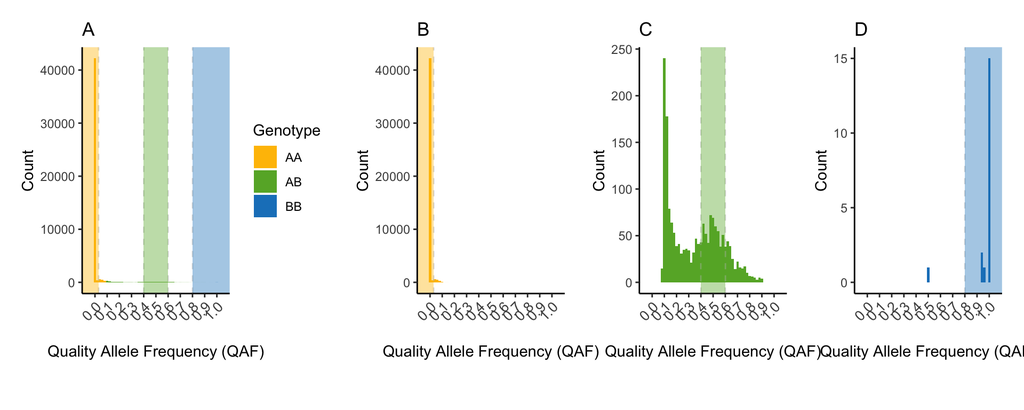

[output not shown]

#### VAF

[figure not shown]

[output not shown]

Based on the distribution of sites’ VAF and QAF values, the following filtering criteria were applied:  
- Homozygous Reference (AA): VAF < 0.03 and QAF < 0.03, sites exhibit low alternate allele support  
- Heterozygous (AB): 0.4 < VAF < 0.6 and 0.4 < QAF < 0.6, sites maintain a balanced allele distribution  
- Homozygous Alternate (BB): VAF > 0.8 and QAF > 0.8, sites demonstrate high alternate allele support

This filtering approach enhances the accuracy of genotype classification while reducing the inclusion of low-confidence variant calls, by minimizing genotyping errors due to sequencing artifacts or depth-related biases.

# Main Figures

## Figure 1A: Crossing F1 mother AB with F1 father AA, one family

*Note: The original analysis can be found in:* - `~/Documents/GitHub/varroa-pedigree-study/R_scripts/After_revision/site_quality_exploration.Rmd`

```r
# Load the fam2_selected data, for one family (478) on the largest chromosome, NW_019211454
fam2_selected <- read.csv("/Users/nuriteliash/Documents/GitHub/varroa-pedigree-study/data/fam2_selected.csv")
```

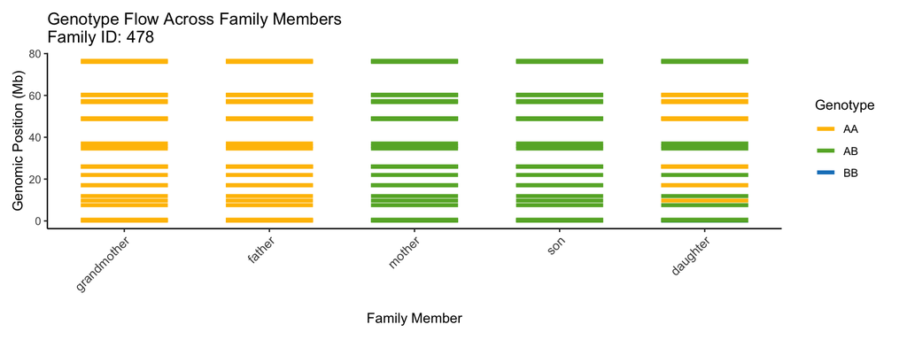

```r
# Create a numeric x-axis for spacing (convert 'member' to factor and assign spacing)
fam_id <- 478

fam2_selected %>%
  ggplot(aes(x = member_num, y = pos / 1e6, color = GT)) +  # Convert pos to Mb
  geom_segment(aes(x = member_num - 0.3, xend = member_num + 0.3,
                   y = pos / 1e6, yend = pos / 1e6), size = 1.5) +  # Apply same conversion
  scale_x_continuous(breaks = unique(fam2_selected$member_num), labels = unique(fam2_selected$member)) +  # Restore original labels
  scale_color_manual(
    values = c("AA" = "#ffbf00", "AB" = "#66b032", "BB" = "#1982c4"),  # Updated colors for renamed genotypes
    name = "Genotype",
    breaks = c("AA", "AB", "BB")  # Ensures BB appears in the legend even if absent
  ) +
  theme_classic() +
  labs(
    title = paste("Genotype Flow Across Family Members\nFamily ID:", fam_id),
    x = "Family Member",
    y = "Genomic Position (Mb)"
  ) +
  theme(
    axis.text.x = element_text(size = 10, angle = 45, hjust = 1, vjust = 1),  # Adjusted text size and angle
    axis.title.x = element_text(margin = margin(t = 15)),  # Add margin above x-axis title
    panel.grid.major = element_blank(),
    legend.position = "right",  # Move legend to the right
    legend.box.margin = margin(0, 0, 0, 10),  # Add margin to separate legend from plot
    plot.margin = margin(10, 20, 30, 10)  # Increased bottom margin to accommodate rotated labels
  )
```

```r
# Add caption below the plot
cat("\n**Figure 1A.** Genotype flow visualization across a single family (Family ID: 478). Each horizontal line represents a genomic position on chromosome NW_019211454.1, with colors indicating genotypes (yellow = AA, green = AB, blue = BB). Family members are arranged in generational order, showing the inheritance pattern from parents to offspring. The y-axis shows the genomic position in megabases (Mb).")
```

```
##
## **Figure 1A.** Genotype flow visualization across a single family (Family ID: 478). Each horizontal line represents a genomic position on chromosome NW_019211454.1, with colors indicating genotypes (yellow = AA, green = AB, blue = BB). Family members are arranged in generational order, showing th…
```

### Analysis of filtered sites (site quality QAF and VAF)

```r
# Load the pre-filtered sites per family and sample
# the file was created using the ~/Documents/GitHub/varroa-pedigree-study/R_scripts/After_revision/site_quality_exploration.Rmd

filtered_sites <- read_csv("/Users/nuriteliash/Documents/GitHub/varroa-pedigree-study/data/filtered_sites.csv") %>%
    mutate(family = as.character(family),
           Sample = as.character(Sample),
           # Extract Chromosome from the site column
           chrom = str_split(site, pattern = "_", simplify = TRUE)[, 2]) %>%
    rename(gt = GT)
```

### Summary of sites filtrered in each sample

Number of sites filtered per sample

| Sample | Total Sites | Sites Kept | Sites Removed | % Removed |
| --- | --- | --- | --- | --- |
| 478_479-1a_grnson | 28898 | 20507 | 8391 | 29.04 |
| 302_303b_grnson | 28367 | 20834 | 7533 | 26.56 |
| 63_64_dat | 30582 | 23434 | 7148 | 23.37 |
| 478_479-1_dat | 27355 | 20486 | 6869 | 25.11 |
| 338_339_dat | 30047 | 23413 | 6634 | 22.08 |
| 564_565-1b_grnson | 25552 | 19418 | 6134 | 24.01 |
| 133_134_dat | 24195 | 18133 | 6062 | 25.05 |
| 302_303_dat | 25317 | 19923 | 5394 | 21.31 |
| 338_339a_grndat | 30321 | 25214 | 5107 | 16.84 |
| 110_111c_grnson | 30064 | 25152 | 4912 | 16.34 |
| 600_601_dat | 21128 | 16387 | 4741 | 22.44 |
| 596_596a_son | 28716 | 24119 | 4597 | 16.01 |
| 498_499c_grndat | 27543 | 23172 | 4371 | 15.87 |
| 498_499a_grnson | 27913 | 23591 | 4322 | 15.48 |
| 520_520_fnd | 29042 | 24817 | 4225 | 14.55 |
| 300_300a_son | 27961 | 23749 | 4212 | 15.06 |
| 284_284a_son | 28711 | 24515 | 4196 | 14.61 |
| 187_188_dat | 30316 | 26227 | 4089 | 13.49 |
| 476_477b_grnson | 28391 | 24347 | 4044 | 14.24 |
| 284_285_dat | 29352 | 25430 | 3922 | 13.36 |
| 564_565-1_dat | 12733 | 8968 | 3765 | 29.57 |
| 300_300_fnd | 22043 | 18345 | 3698 | 16.78 |
| 110_111_dat | 20695 | 17022 | 3673 | 17.75 |
| 133_133a_son | 28760 | 25406 | 3354 | 11.66 |
| 284_285b_grndat | 30316 | 27021 | 3295 | 10.87 |
| 600_601a_grnson | 12873 | 9581 | 3292 | 25.57 |
| 43_44_dat | 28703 | 25429 | 3274 | 11.41 |
| 548_548_fnd | 21544 | 18275 | 3269 | 15.17 |
| 534_534a_son | 18886 | 15730 | 3156 | 16.71 |
| 534_534_fnd | 19995 | 16853 | 3142 | 15.71 |

[output cut: 107 more lines]

```
##
## *Note: Scroll to see all rows in the table.*
```

### Filtered for QAF and VAF, minimum sites per sample = 40

*Click the code button to view the analysis with minimum 40 sites per sample*

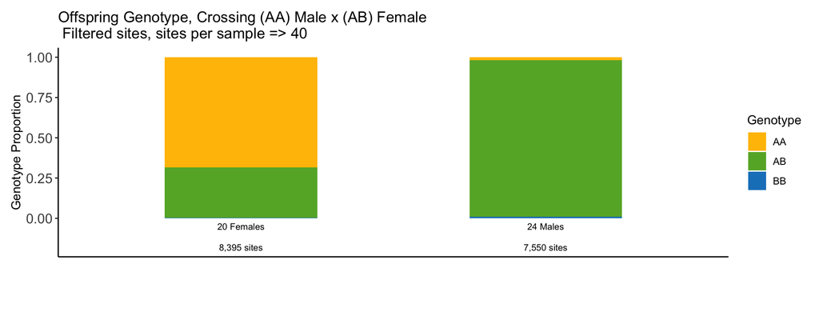

```r
# filtered samples, at least 40 sites per sample
site_threshold = as.numeric(40)

## filtered sites

# Create summary dataframe for labels, summing across all chromosomes (for pulled data only)
summary_df_filtered <- samples_obs_filtered %>%
  group_by(sex) %>%  # Remove chromosome grouping
  summarise(
    num_samples = n_distinct(Sample),  # Count unique samples
    total_sites = sum(total, na.rm = TRUE),  # Sum all sites
    .groups = 'drop'
  )

# Create per-chromosome summary for faceted plot
summary_df_filtered_by_chrom <- samples_obs_filtered %>%
  group_by(chrom, sex) %>%
  summarise(
    num_samples = n_distinct(Sample),
    total_sites = sum(total, na.rm = TRUE),
    .groups = 'drop'
  )

# Plot 1: Pulled data with totals across all chromosomes
ggplot(samples_obs_filtered %>% filter(total >= site_threshold),
       aes(fill = gt, y = prop, x = factor(sex, levels = c("Female", "Male")))) +
  geom_bar(position = "fill", stat = "identity", width = 0.5) +
  ylab("Genotype Proportion") +
  labs(title = "Offspring Genotype, Crossing (AA) Male x (AB) Female
 Filtered sites, sites per sample => 40",
       fill = "Genotype") +
  theme_classic() +
  theme(
    axis.title.x = element_blank(),
    axis.text.x = element_blank(),
    axis.ticks.x = element_blank(),
    axis.text.y = element_text(size = 12),
    strip.text.x = element_text(size = 12),
    panel.spacing = unit(1, "lines"),
    plot.margin = margin(t = 10, r = 10, b = 60, l = 10)
  ) +
  scale_fill_manual(values = c("#ffbf00", "#66b032", "#1982c4")) +
  # Add sample count labels (only for pulled data)
  geom_text(data = summary_df_filtered,
            aes(x = sex,
                y = -0.03,
                label = paste0(num_samples, " ", sex, "s")),
            inherit.aes = FALSE,
            size = 2.8,
            vjust = 1) +
  # Add total sites label with comma formatting (only for pulled data)
  geom_text(data = summary_df_filtered,
            aes(x = sex,
                y = -0.18,
                label = paste0(format(total_sites, big.mark = ","), " sites")),
            inherit.aes = FALSE,
            size = 2.8,
            vjust = 0.5)
```

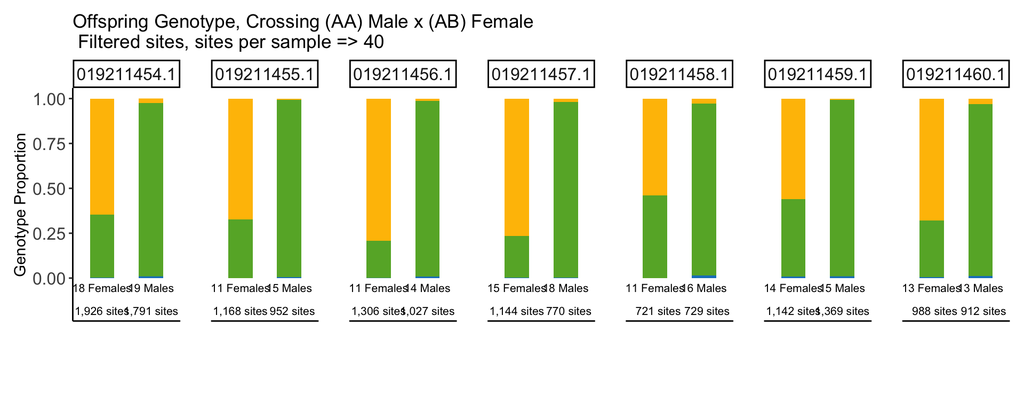

```r
# Plot 2: Faceted plot by chromosome (with per-chromosome statistics)
ggplot(samples_obs_filtered %>% filter(total >= site_threshold),
       aes(fill = gt, y = prop, x = factor(sex, levels = c("Female", "Male")))) +
  geom_bar(position = "fill", stat = "identity", width = 0.5) +
  facet_wrap(~chrom, nrow = 1) +
  ylab("Genotype Proportion") +
  labs(title = "Offspring Genotype, Crossing (AA) Male x (AB) Female
 Filtered sites, sites per sample => 40",
       fill = "Genotype") +
  theme_classic() +
  theme(
    axis.title.x = element_blank(),
    axis.text.x = element_blank(),
    axis.ticks.x = element_blank(),
    axis.text.y = element_text(size = 12),
    strip.text.x = element_text(size = 12),
    panel.spacing = unit(1.5, "lines"),  # Increased panel spacing
    plot.margin = margin(t = 10, r = 10, b = 60, l = 10),
    legend.position = "none"  # Remove legend
  ) +
  scale_fill_manual(values = c("#ffbf00", "#66b032", "#1982c4")) +
  # Add sample count labels per chromosome
  geom_text(data = summary_df_filtered_by_chrom,
            aes(x = sex,
                y = -0.03,
                label = paste0(num_samples, " ", sex, "s")),
            inherit.aes = FALSE,
            size = 2.8,
            vjust = 1) +
  # Add sites count labels per chromosome
  geom_text(data = summary_df_filtered_by_chrom,
            aes(x = sex,
                y = -0.18,
                label = paste0(format(total_sites, big.mark = ","), " sites")),
            inherit.aes = FALSE,
            size = 2.8,
            vjust = 0.5)
```

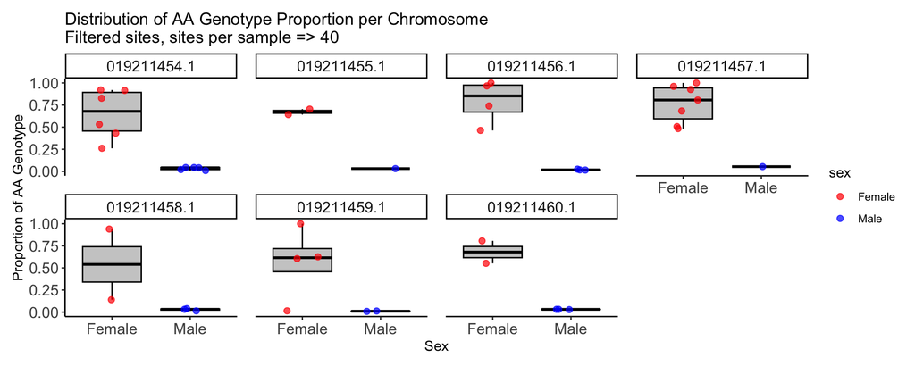

```r
# Plot 3: Box plot remains unchanged
ggplot(samples_obs_filtered %>%
       filter(total >= site_threshold) %>%
       filter(gt == "AA"),
       aes(x = factor(sex, levels = c("Female", "Male")), y = prop, color = sex)) +
  geom_boxplot(fill = "grey80", outlier.shape = NA, color = "black") +
  geom_point(position = position_jitter(width = 0.2), size = 2, alpha = 0.7) +
  facet_wrap(~chrom, nrow = 2) +
  ylab("Proportion of AA Genotype") +
  xlab("Sex") +
  labs(title = "Distribution of AA Genotype Proportion per Chromosome
Filtered sites, sites per sample => 40") +
  theme_classic() +
  theme(
    strip.background = element_rect(fill = "white", color = "black"),
    axis.text = element_text(size = 12),
    strip.text = element_text(size = 12),
    panel.spacing = unit(1, "lines"),
    plot.margin = margin(t = 10, r = 10, b = 10, l = 10)
  ) +
  scale_color_manual(values = c("Female" = "red", "Male" = "blue")) +
  coord_cartesian(ylim = c(0, 1))
```

```r
# Add captions below each plot
cat("\n**Figure 1B.** Distribution of genotypes in offspring from crosses between AA males and AB females, showing filtered sites with minimum 40 sites per sample. Top panel shows overall proportions across all chromosomes, while bottom panel shows chromosome-specific distributions. Bar heights represent the proportion of each genotype (AA, AB, BB) in males and females, with sample sizes and total site counts indicated below each bar.")
```

```
##
## **Figure 1B.** Distribution of genotypes in offspring from crosses between AA males and AB females, showing filtered sites with minimum 40 sites per sample. Top panel shows overall proportions across all chromosomes, while bottom panel shows chromosome-specific distributions. Bar heights represen…
```

```r
cat("\n**Figure 1C.** Boxplot distribution of AA genotype proportions across chromosomes in male and female offspring. Each point represents an individual sample, with boxes showing the median and quartile ranges. Data is filtered to include only samples with 40 or more sites. The plot demonstrates sex-specific differences in AA genotype frequency across all seven chromosomes.")
```

```
##
## **Figure 1C.** Boxplot distribution of AA genotype proportions across chromosomes in male and female offspring. Each point represents an individual sample, with boxes showing the median and quartile ranges. Data is filtered to include only samples with 40 or more sites. The plot demonstrates sex-…
```

# Supplementary Figures for Manuscript

```
## Summary of variant quality scores:
```

```
##      Min.   1st Qu.    Median      Mean   3rd Qu.      Max.
##     40.48  33240.80  48198.10  52338.46  69672.30 191031.00
```

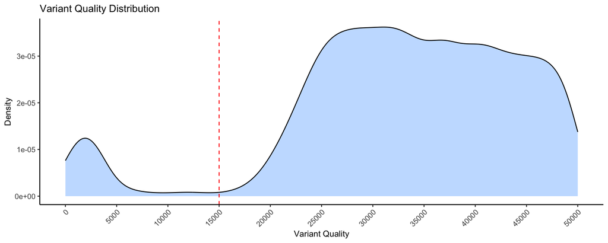

[output not shown]

## Karyotyping of males and females (Figure S 3A)

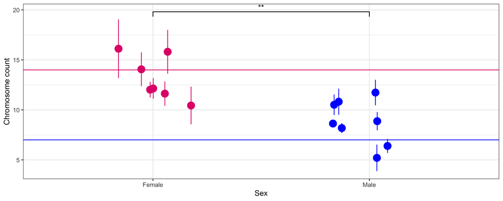

```r
dat <- read_csv("/Users/nuriteliash/Documents/GitHub/varroa-karyotyping/data/karyo_varroa_sasha.csv", col_types = "cccnnn")

dat_means <- dat %>% group_by(ID) %>%
    reframe(
        chroms = sum(cell_count * chromo_number) / sum(cell_count),
        count = sum(cell_count),
        sd = sqrt(sum(cell_count * (chromo_number - chroms)^2) / sum(cell_count)),
        sem = sd / sqrt(count),
        ci_lower = chroms - qt(0.975, df = count - 1) * sem,
        ci_upper = chroms + qt(0.975, df = count - 1) * sem,
        sex = Sex[1])

dat_means %>%
ggplot(aes(x = sex, y = chroms, color = sex, size = count)) +
  geom_pointrange(aes(ymin = ci_lower, ymax = ci_upper), size = 1, width = 0.05, position=position_jitter(width=0.2)) +
  scale_color_manual(values = c("Male" = "blue", "Female" = "#E31C79")) +  # Custom colors
  scale_size_continuous(range = c(3, 10)) +  # Custom size range
  geom_hline(yintercept = 7, color = "blue") +
  geom_hline(yintercept = 14, color = "#E31C79") +
  theme_bw() +
  ylab("Chromosome count") +
  geom_signif(comparisons = list(c("Male", "Female")), map_signif_level = TRUE, test = "wilcox.test", color = "black") +
  scale_y_continuous(breaks = scales::breaks_pretty()) +
  theme(legend.position = "bottom") +
  guides(color = "none") +
  labs(size = "Number of cells examined per individual") +
  xlab("Sex")
```

```r
#ggsave("karyptype.pdf", heigh=5, width=5)
```

Do males have significantly less chromosomes than the diploid number of 14?

```r
filter(dat_means, sex == "Male") %>% pull(chroms) %>% t.test(., mu = 14)
```

```
##
##  One Sample t-test
##
## data:  .
## t = -6.5908, df = 7, p-value = 0.0003069
## alternative hypothesis: true mean is not equal to 14
## 95 percent confidence interval:
##   6.926898 10.662108
## sample estimates:
## mean of x
##  8.794503
```